# Testing the input and output of CTmeta

# PrintPlot (TRUE/FALSE or 0/1; optional)

## PrintPlot = 2

```r
CTma.break <- CTmeta::CTmeta(N,
               DeltaT,
               DeltaTStar,
               Phi,
               SigmaVAR,
               PrintPlot = 2)
CTma.break
```

```
## [1] "The argument 'PrintPlot' should be T(RUE) or F(ALSE); or 1 or 0; not 2"
```

```r
# "The argument 'PrintPlot' should be T(RUE) or F(ALSE); or 1 or 0; not 2"
```

To do: - turn this into a warning: the rest can still run

Done:

```r
CTma.break <- CTmeta(N,
               DeltaT,
               DeltaTStar,
               Phi,
               SigmaVAR,
               PrintPlot = 2)
```

```
## Warning in CTmeta(N, DeltaT, DeltaTStar, Phi, SigmaVAR, PrintPlot = 2): The
## argument 'PrintPlot' should be T(RUE) or F(ALSE) (or 1 or 0), not 2
```

```r
CTma.break
```

```
##
## The overall estimates obtained with CTmeta and their 95% elliptical/multivariate confidence interval:
##
##              Overall_Phi LB     UB
## overallPhi11 0.519       0.4771 0.562
## overallPhi12 0.139       0.0964 0.181
## overallPhi21 0.198       0.1638 0.233
## overallPhi22 0.624       0.5897 0.659
##
## CTmeta Messages:
## - All eigenvalues are positive and real. Therefore, the 'Phi's are transformed to Phi(DeltaT*) to account for the time-interval dependency and are standardized to make comparison of effects meaningful.
## - For each study, the covariance matrix is positive definite. Therefore, a multivariate approach is used.
```

```r
summary(CTma.break) == summary(CTma)
```

```
## [1] TRUE
```

## PrintPlot for FE with moderator

```r
CTma.mod.break <- CTmeta::CTmeta(N,
               DeltaT,
               DeltaTStar,
               Phi,
               SigmaVAR,
               Moderators = 1,
               Mod = Mod,
               PrintPlot = TRUE) %>%
  try()
```

```
## Error : $ operator is invalid for atomic vectors
```

```r
# Warning in log(Eigen_ParamVAR) : NaNs produced Error: $ operator is invalid for atomic vectors
```

To do: - why is this going wrong?

Done:

```r
CTma.mod.break <- CTmeta(N,
               DeltaT,
               DeltaTStar,
               Phi,
               SigmaVAR,
               Moderators = 1,
               Mod = Mod,
               PrintPlot = TRUE)
```

```
## Error in ggPhiPlot(DeltaTStar, overallPhi, Min = min, Max = max, Step = step,  :
##   'Phi' does not have a CTM-equivalent drift matrix. That is, there is no positive autocorrelation (as in the first-order continuous-time models), since one or more eigenvalues (have real parts which) are negative.
```

```
##
##  The model was fit, but the Phi-plot could not be produced: 'Phi' does not have a CTM-equivalent drift matrix. That is, there is no positive autocorrelation (as in the first-order continuous-time models), since one or more eigenvalues (have real parts which) are negative.
```

```r
CTma.mod.break
```

```
##
## The overall estimates obtained with CTmeta and their 95% elliptical/multivariate confidence interval:
##
##              Overall_Phi LB     UB
## overallPhi11 -1.082      -1.460 -0.7029
## overallPhi12 -0.390      -0.769 -0.0117
## overallPhi21 -0.159      -0.519  0.2014
## overallPhi22 -0.911      -1.272 -0.5512
##
## CTmeta Messages:
## - All eigenvalues are positive and real. Therefore, the 'Phi's are transformed to Phi(DeltaT*) to account for the time-interval dependency and are standardized to make comparison of effects meaningful.
## - For each study, the covariance matrix is positive definite. Therefore, a multivariate approach is used.
```

```r
summary(CTma.mod.break) == summary(CTma.mod)
```

```
## [1] TRUE
```

## PrintPlot for FE without moderator

```r
CTma.mod.break <- CTmeta::CTmeta(N,
               DeltaT,
               DeltaTStar,
               Phi,
               SigmaVAR,
               PrintPlot = TRUE)
# this returns the plot twice

CTma.mod.break
```

```
##
## The overall estimates obtained with CTmeta and their 95% elliptical/multivariate confidence interval:
##
##              Overall_Phi LB     UB
## overallPhi11 0.519       0.4771 0.562
## overallPhi12 0.139       0.0964 0.181
## overallPhi21 0.198       0.1638 0.233
## overallPhi22 0.624       0.5897 0.659
##
## CTmeta Messages:
## - All eigenvalues are positive and real. Hence, the Phi's are transformed to Phi(DeltaT*) to account for the time-interval dependency and standardized (to make comparison of effects meaningful).
## - For each study, the covariance matrix is positive definite. Hence, a multivariate approach is used.
```

```r
summary(CTma.mod.break) == summary(CTma)
```

```
## [1] TRUE
```

To do: - make the plot only print once

When PrintPlot = TRUE, ggPhiPlot is run and saved in a variable. We test whether ggPhiPlot prints when it is saved.

```r
Phi.test <- myPhi[1:2,1:2]

phi_plot <- ggPhiPlot(DeltaTStar, Phi.test)
```

ggPhiPlot does print as it saves. We modify the function CTmeta to take out the print() command.

Testing this worked:

```r
CTma.break <- CTmeta(N,
               DeltaT,
               DeltaTStar,
               Phi,
               SigmaVAR,
               PrintPlot = TRUE)

CTma.break
```

```
##
## The overall estimates obtained with CTmeta and their 95% elliptical/multivariate confidence interval:
##
##              Overall_Phi LB     UB
## overallPhi11 0.519       0.4771 0.562
## overallPhi12 0.139       0.0964 0.181
## overallPhi21 0.198       0.1638 0.233
## overallPhi22 0.624       0.5897 0.659
##
## CTmeta Messages:
## - All eigenvalues are positive and real. Therefore, the 'Phi's are transformed to Phi(DeltaT*) to account for the time-interval dependency and are standardized to make comparison of effects meaningful.
## - For each study, the covariance matrix is positive definite. Therefore, a multivariate approach is used.
```

```r
summary(CTma.break) == summary(CTma)
```

```
## [1] TRUE
```

```r
CTma.break$PhiPlot
```

## PrintPlot for RE with moderator

```r
CTma.mod.break <- CTmeta::CTmeta(N,
               DeltaT,
               DeltaTStar,
               Phi,
               SigmaVAR,
               FEorRE = 2,
               Moderators = 1,
               Mod = Mod,
               PrintPlot = TRUE) %>%
  try()
```

```
## Error : $ operator is invalid for atomic vectors
```

```r
# Warning in log(Eigen_ParamVAR) : NaNs produced Error: $ operator is invalid for atomic vectors
```

To do: - why is this going wrong?

Done:

```r
CTma.mod.RE <- CTmeta::CTmeta(N,
               DeltaT,
               DeltaTStar,
               Phi,
               SigmaVAR,
               FEorRE = 2,
               Moderators = 1,
               Mod = Mod)

CTma.mod.RE.break <- CTmeta(N,
               DeltaT,
               DeltaTStar,
               Phi,
               SigmaVAR,
               FEorRE = 2,
               Moderators = 1,
               Mod = Mod,
               PrintPlot = TRUE)
```

```
## Error in ggPhiPlot(DeltaTStar, overallPhi, Min = min, Max = max, Step = step,  :
##   'Phi' does not have a CTM-equivalent drift matrix. That is, there is no positive autocorrelation (as in the first-order continuous-time models), since one or more eigenvalues (have real parts which) are negative.
```

```
##
##  The model was fit, but the Phi-plot could not be produced: 'Phi' does not have a CTM-equivalent drift matrix. That is, there is no positive autocorrelation (as in the first-order continuous-time models), since one or more eigenvalues (have real parts which) are negative.
```

```r
CTma.mod.RE.break
```

```
##
## The overall estimates obtained with CTmeta and their 95% elliptical/multivariate confidence interval:
##
##              Overall_Phi LB     UB
## overallPhi11 -1.019      -1.924 -0.114
## overallPhi12 -0.340      -0.869  0.188
## overallPhi21 -0.125      -0.605  0.354
## overallPhi22 -0.846      -1.577 -0.114
##
## Note: A random-effects model is used. The tau^2 values can be obtained via '$tau2'; see '$summaryMetaAnalysis' for more information.
##
## CTmeta Messages:
## - All eigenvalues are positive and real. Therefore, the 'Phi's are transformed to Phi(DeltaT*) to account for the time-interval dependency and are standardized to make comparison of effects meaningful.
## - For each study, the covariance matrix is positive definite. Therefore, a multivariate approach is used.
```

```r
summary(CTma.mod.RE.break) == summary(CTma.mod.RE)
```

```
## [1] TRUE
```

## PrintPlot for RE without moderator

```r
CTma.mod.break <- CTmeta::CTmeta(N,
               DeltaT,
               DeltaTStar,
               Phi,
               SigmaVAR,
               FEorRE = 2,
               PrintPlot = TRUE)
# this returns the plot twice

CTma.mod.break
```

```
##
## The overall estimates obtained with CTmeta and their 95% elliptical/multivariate confidence interval:
##
##              Overall_Phi LB      UB
## overallPhi11 0.4339       0.0527 0.815
## overallPhi12 0.0828      -0.0244 0.190
## overallPhi21 0.1527       0.0955 0.210
## overallPhi22 0.5295       0.1783 0.881
##
## Note: A random-effects model is used. The tau^2 values can be obtained via '$tau2'; see '$summaryMetaAnalysis' for more information.
##
## CTmeta Messages:
## - All eigenvalues are positive and real. Hence, the Phi's are transformed to Phi(DeltaT*) to account for the time-interval dependency and standardized (to make comparison of effects meaningful).
## - For each study, the covariance matrix is positive definite. Hence, a multivariate approach is used.
```

```r
summary(CTma.mod.break) == summary(CTma.RE.noBL)
```

```
## [1] TRUE
```

To do: - make the plot only print once

Done:

```r
CTma.mod.break <- CTmeta(N,
               DeltaT,
               DeltaTStar,
               Phi,
               SigmaVAR,
               FEorRE = 2,
               PrintPlot = TRUE)

CTma.mod.break
```

```
##
## The overall estimates obtained with CTmeta and their 95% elliptical/multivariate confidence interval:
##
##              Overall_Phi LB      UB
## overallPhi11 0.4339       0.0527 0.815
## overallPhi12 0.0828      -0.0244 0.190
## overallPhi21 0.1527       0.0955 0.210
## overallPhi22 0.5295       0.1783 0.881
##
## Note: A random-effects model is used. The tau^2 values can be obtained via '$tau2'; see '$summaryMetaAnalysis' for more information.
##
## CTmeta Messages:
## - All eigenvalues are positive and real. Therefore, the 'Phi's are transformed to Phi(DeltaT*) to account for the time-interval dependency and are standardized to make comparison of effects meaningful.
## - For each study, the covariance matrix is positive definite. Therefore, a multivariate approach is used.
```

```r
summary(CTma.mod.break) == summary(CTma.RE.noBL)
```

```
## [1] TRUE
```

```r
CTma.mod.break$PhiPlot
```

## PrintPlot for RE without moderator, specified BetweenLevel

```r
CTma.mod.break <- CTmeta::CTmeta(N,
               DeltaT,
               DeltaTStar,
               Phi,
               SigmaVAR,
               FEorRE = 2,
               BetweenLevel = BetweenLevel,
               PrintPlot = TRUE)
# this returns the plot twice

CTma.mod.break
```

```
##
## The overall estimates obtained with CTmeta and their 95% elliptical/multivariate confidence interval:
##
##              Overall_Phi LB     UB
## overallPhi11 0.4198       0.141 0.699
## overallPhi12 0.0391      -0.240 0.318
## overallPhi21 0.0903      -0.188 0.369
## overallPhi22 0.5161       0.238 0.795
##
## Note: A random-effects model is used. The tau^2 values can be obtained via '$tau2'; see '$summaryMetaAnalysis' for more information.
##
## CTmeta Messages:
## - All eigenvalues are positive and real. Hence, the Phi's are transformed to Phi(DeltaT*) to account for the time-interval dependency and standardized (to make comparison of effects meaningful).
## - For each study, the covariance matrix is positive definite. Hence, a multivariate approach is used.
```

```r
summary(CTma.mod.break) == summary(CTma.RE)
```

```
## [1] TRUE
```

To do: - make the plot only print once

Done:

```r
CTma.mod.break <- CTmeta(N,
               DeltaT,
               DeltaTStar,
               Phi,
               SigmaVAR,
               FEorRE = 2,
               BetweenLevel = BetweenLevel,
               PrintPlot = TRUE)

CTma.mod.break
```

```
##
## The overall estimates obtained with CTmeta and their 95% elliptical/multivariate confidence interval:
##
##              Overall_Phi LB     UB
## overallPhi11 0.4198       0.141 0.699
## overallPhi12 0.0391      -0.240 0.318
## overallPhi21 0.0903      -0.188 0.369
## overallPhi22 0.5161       0.238 0.795
##
## Note: A random-effects model is used. The tau^2 values can be obtained via '$tau2'; see '$summaryMetaAnalysis' for more information.
##
## CTmeta Messages:
## - All eigenvalues are positive and real. Therefore, the 'Phi's are transformed to Phi(DeltaT*) to account for the time-interval dependency and are standardized to make comparison of effects meaningful.
## - For each study, the covariance matrix is positive definite. Therefore, a multivariate approach is used.
```

```r
summary(CTma.mod.break) == summary(CTma.RE)
```

```
## [1] TRUE
```

```r
CTma.mod.break$PhiPlot
```

# Funnel and forest plots

## FE model with moderator

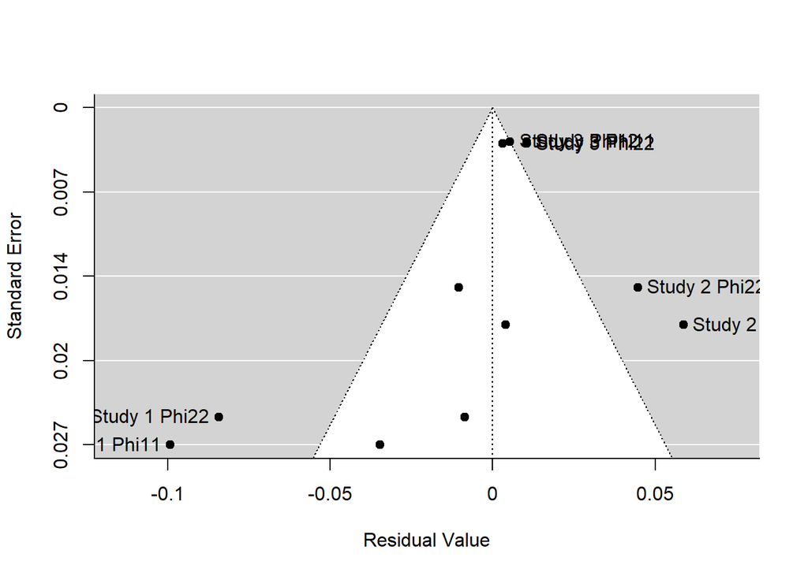

```r
CTma.FE.mod <- CTmeta(N,
               DeltaT,
               DeltaTStar,
               Phi,
               SigmaVAR,
               Moderators = 1,
               Mod = Mod)

funnel(CTma.FE.mod$summaryMetaAnalysis, label = 'out')
```

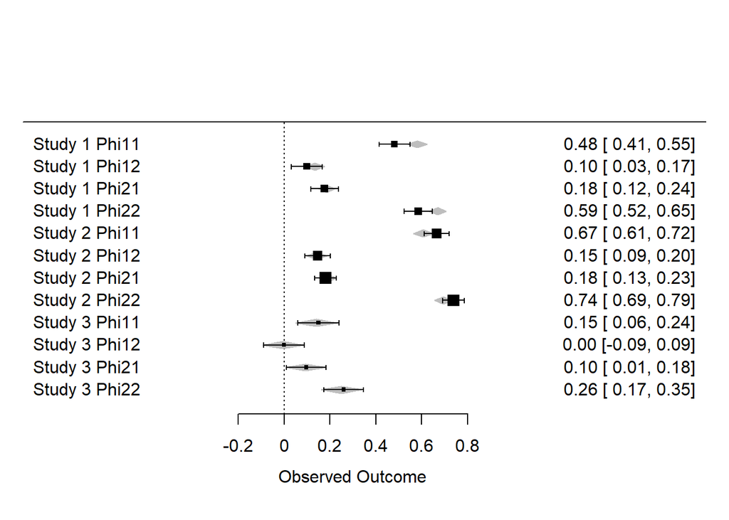

```r
forest(CTma.FE.mod$summaryMetaAnalysis)
```

To do: - nothing, both work

## FE model without moderator

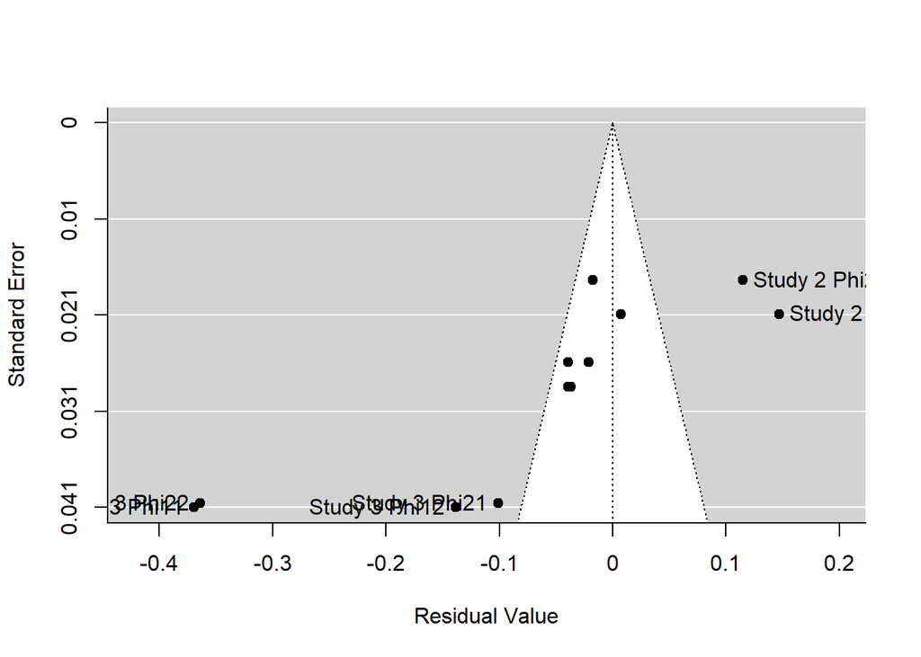

```r
CTma.FE.nomod <- CTmeta(N,
               DeltaT,
               DeltaTStar,
               Phi,
               SigmaVAR)

funnel(CTma.FE.nomod$summaryMetaAnalysis, label = 'out')
```

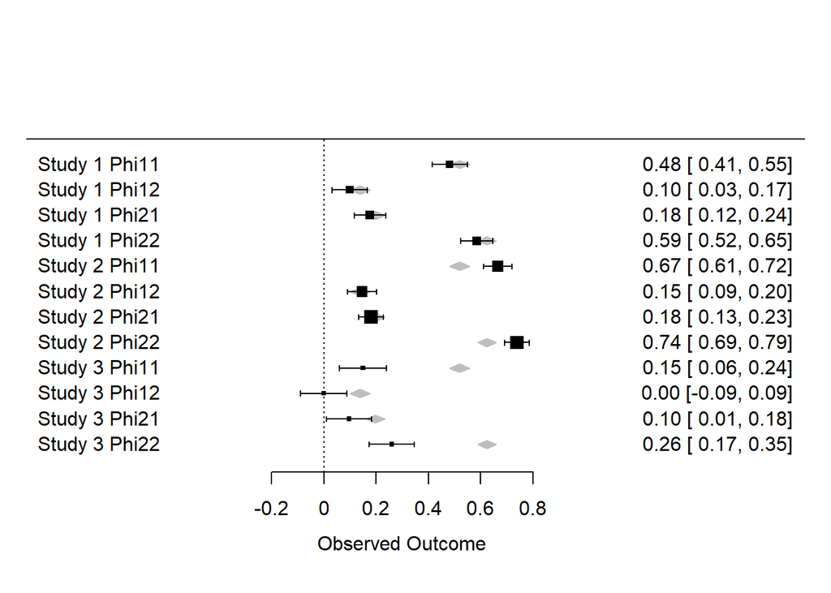

```r
forest(CTma.FE.nomod$summaryMetaAnalysis)
```

To do: - nothing, both work

## RE model with moderator and no BetweenLevel

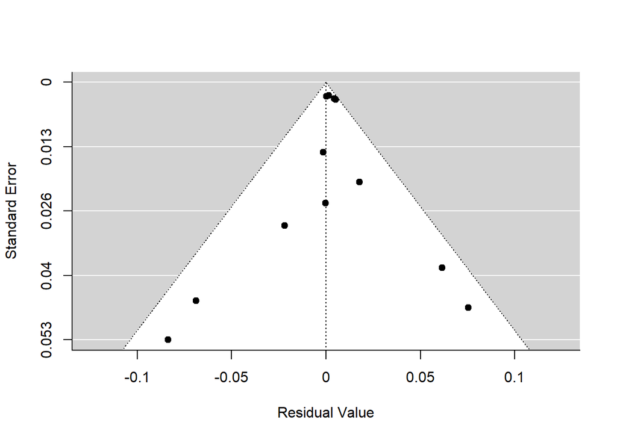

```r
CTma.RE.mod <- CTmeta(N,
               DeltaT,
               DeltaTStar,
               Phi,
               SigmaVAR,
               FEorRE = 2,
               Moderators = 1,
               Mod = Mod)

funnel(CTma.RE.mod$summaryMetaAnalysis, label = 'out')
```

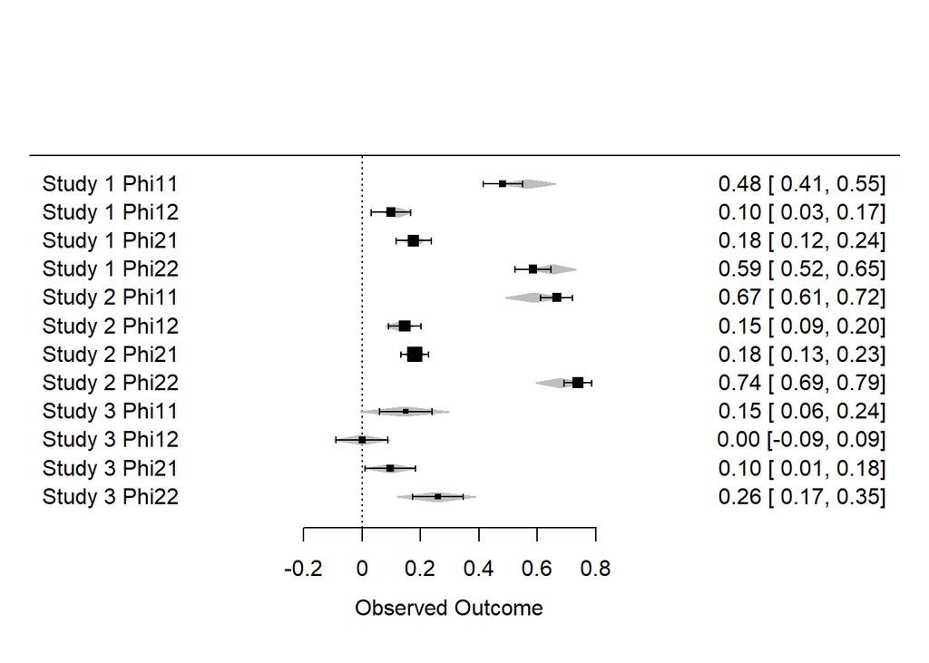

```r
forest(CTma.RE.mod$summaryMetaAnalysis)
```

To do: - nothing, both work

## RE model without moderator and no BetweenLevel

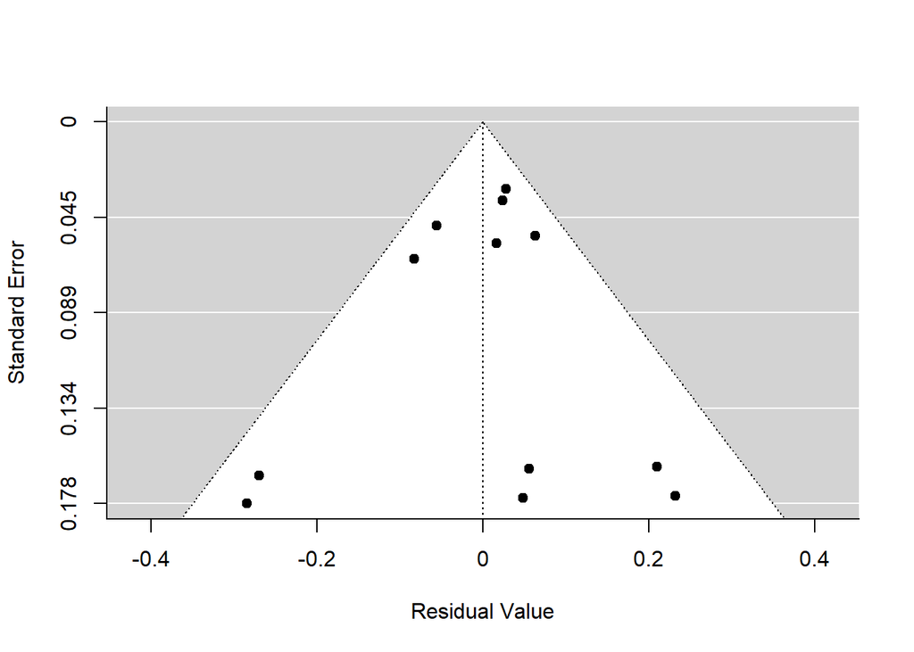

```r
CTma.RE.nomod <- CTmeta(N,
               DeltaT,
               DeltaTStar,
               Phi,
               SigmaVAR,
               FEorRE = 2)

funnel(CTma.RE.nomod$summaryMetaAnalysis, label = 'out')
```

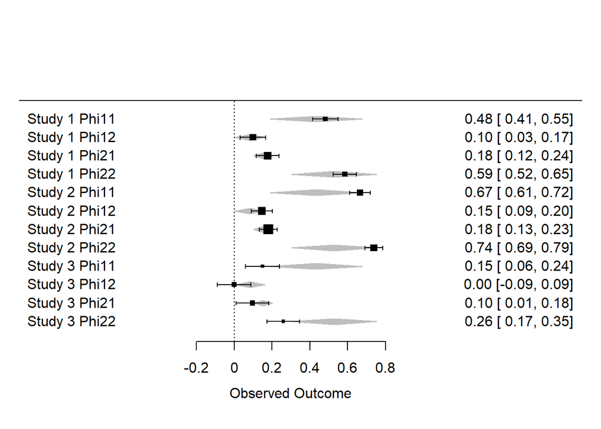

```r
forest(CTma.RE.nomod$summaryMetaAnalysis)
```

To do: - nothing, both work

## RE model with moderator and BetweenLevel

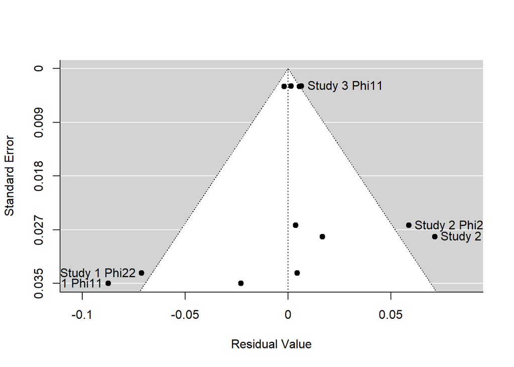

```r
CTma.RE.mod.BL <- CTmeta(N,
               DeltaT,
               DeltaTStar,
               Phi,
               SigmaVAR,
               FEorRE = 2,
               Moderators = 1,
               Mod = Mod,
               BetweenLevel = BetweenLevel)

funnel(CTma.RE.mod.BL$summaryMetaAnalysis, label = 'out')
```

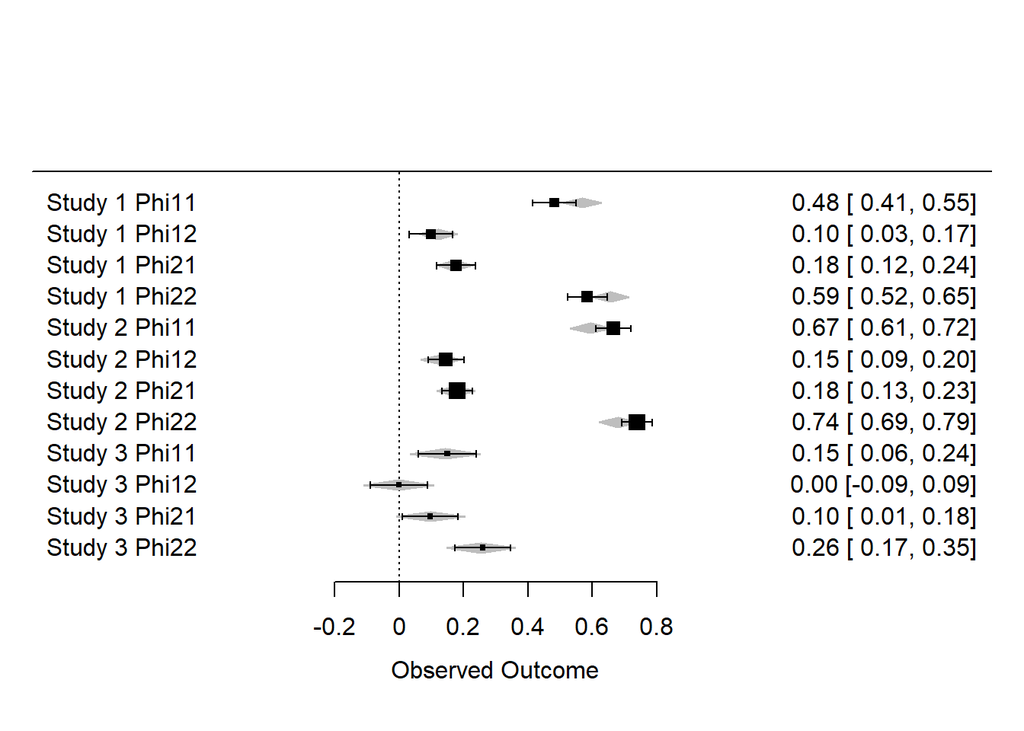

```r
forest(CTma.RE.mod.BL$summaryMetaAnalysis)
```

To do: - nothing, both work

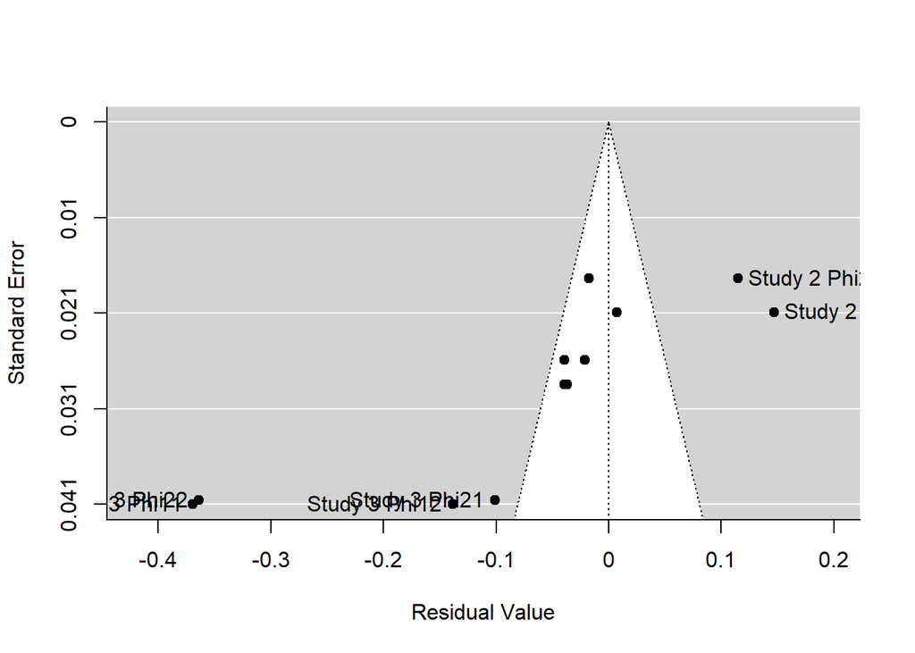

```r
CTma.RE.nomod.BL <- CTmeta(N,
               DeltaT,
               DeltaTStar,
               Phi,
               SigmaVAR,
               Mod = Mod,
               BetweenLevel = BetweenLevel)
funnel(CTma.RE.nomod.BL$summaryMetaAnalysis, label = 'out')
```

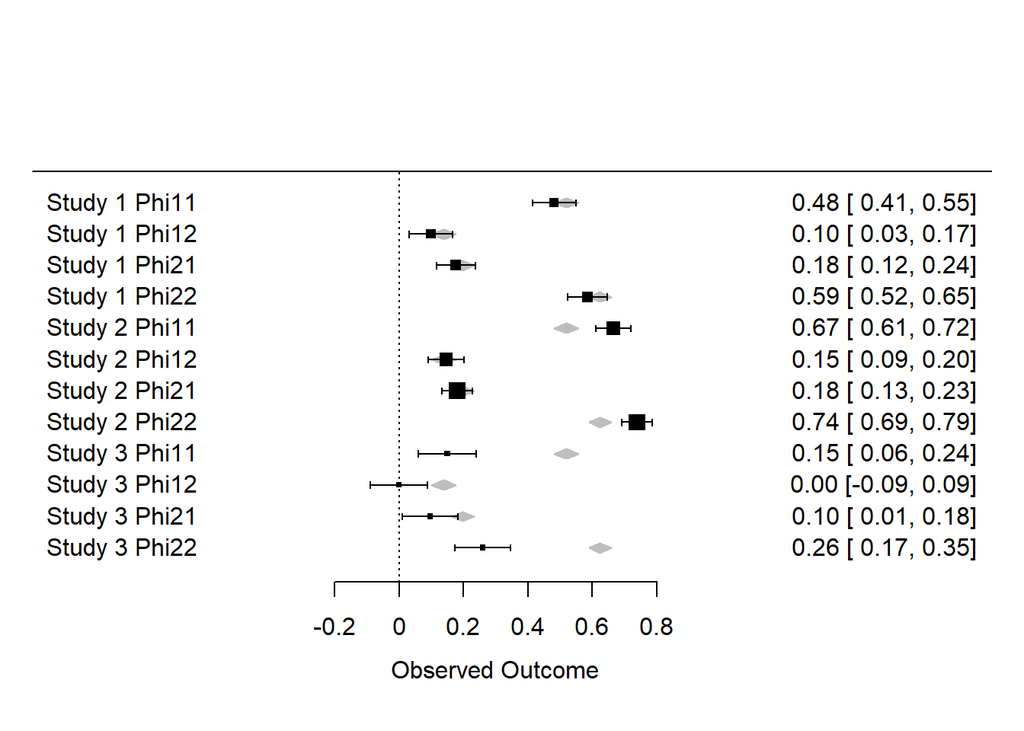

```r
forest(CTma.RE.nomod.BL$summaryMetaAnalysis)
```

To do: - nothing, both work

# GORICA

## FE model with moderator

```r
library(restriktor)
H1 <- "abs(overallPhi12) < abs(overallPhi21)"

goric(CTma.FE.mod, H1, type = "gorica", comparison = "complement")
```

```
## restriktor (0.3-100): generalized order-restriced information criterion approximation:
##
## Results:
##         model  loglik  penalty  gorica  gorica.weights
## 1          H1   2.895    3.500   1.210           0.390
## 2  complement   3.344    3.500   0.312           0.610
## ---
## The order-restricted hypothesis 'H1' has  0.638 times more support than its complement.
```

## FE model without moderator

```r
goric(CTma.FE.nomod, H1, type = "gorica", comparison = "complement")
```

```
## restriktor (0.3-100): generalized order-restriced information criterion approximation:
##
## Results:
##         model  loglik  penalty   gorica  gorica.weights
## 1          H1  12.370    3.500  -17.739           0.936
## 2  complement   9.690    3.500  -12.379           0.064
## ---
## The order-restricted hypothesis 'H1' has 14.584 times more support than its complement.
```

## RE model with moderator

```r
goric(CTma.RE.mod, H1, type = "gorica", comparison = "complement")
```

```
## restriktor (0.3-100): generalized order-restriced information criterion approximation:
##
## Results:
##         model  loglik  penalty  gorica  gorica.weights
## 1          H1   2.180    3.500   2.640           0.411
## 2  complement   2.540    3.500   1.919           0.589
## ---
## The order-restricted hypothesis 'H1' has  0.698 times more support than its complement.
```

## RE model without moderator

```r
goric(CTma.RE.nomod, H1, type = "gorica", comparison = "complement")
```

```
## restriktor (0.3-100): generalized order-restriced information criterion approximation:
##
## Results:
##         model  loglik  penalty   gorica  gorica.weights
## 1          H1  10.007    3.500  -13.013           0.934
## 2  complement   7.364    3.500   -7.728           0.066
## ---
## The order-restricted hypothesis 'H1' has 14.047 times more support than its complement.
```

To do: - nothing, these all work

# Only specifying some arguments

## Only N

```r
CTma.break <- CTmeta(N) %>%
  try()
```

```
## Error in CTmeta(N) :
##   l'argument "Phi" est manquant, avec aucune valeur par défaut
```

```r
# Error in CTmeta(N) : argument "DeltaT" is missing, with no default
```

### Then fixing that

```r
CTma.break <- CTmeta(N, DeltaT) %>%
  try()
```

```
## Error in CTmeta(N, DeltaT) :
##   l'argument "Phi" est manquant, avec aucune valeur par défaut
```

```r
# argument "DeltaTStar" is missing, with no default
```

### Then fixing that

```r
CTma.break <- CTmeta(N, DeltaT, DeltaTStar) %>%
  try()
```

```
## Error in CTmeta(N, DeltaT, DeltaTStar) :
##   l'argument "Phi" est manquant, avec aucune valeur par défaut
```

```r
# argument "Phi" is missing, with no default
```

### Then fixing that

```r
CTma.break <- CTmeta(N, DeltaT, DeltaTStar, Phi) %>%
  try()
```

```
## Error in CTmeta(N, DeltaT, DeltaTStar, Phi) :
##   The arguments SigmaVAR and Gamma are not specified. One of them must be specified. If specifying SigmaVAR, do not forget the name the argument (i.e., specify 'SigmaVAR = yourSigmaVAR'.
```

### Then fixing that

```r
CTma.break <- CTmeta(N, DeltaT, DeltaTStar, Phi, SigmaVAR)
```

```r
CTma.break <- CTmeta(N, DeltaT, DeltaTStar, Phi, Gamma = Gamma)
CTma.break
```

```
##
## The overall estimates obtained with CTmeta and their 95% elliptical/multivariate confidence interval:
##
##              Overall_Phi LB     UB
## overallPhi11 0.519       0.4771 0.562
## overallPhi12 0.139       0.0964 0.181
## overallPhi21 0.198       0.1638 0.233
## overallPhi22 0.624       0.5897 0.659
##
## CTmeta Messages:
## - All eigenvalues are positive and real. Therefore, the 'Phi's are transformed to Phi(DeltaT*) to account for the time-interval dependency and are standardized to make comparison of effects meaningful.
## - For each study, the covariance matrix is positive definite. Therefore, a multivariate approach is used.
```

```r
summary(CTma.break) == summary(CTma)
```

```
## [1] TRUE
```

### Conclusion:

No need to worry about not specifying an argument that is needed. The errors are clear.